# Ceteris paribus plots of multiagent model of volatility clustering on financial markets

31 - 03 - 2019

```r
load("D:/Alicja/micro_work/Simulation_Models_DALEX/ceteris_paribus/ceteris_paribus_results.rda")
load("D:/Alicja/micro_work/Simulation_Models_DALEX/ceteris_paribus/ibd/ibd_lists_cor.rda")
load("D:/Alicja/micro_work/Simulation_Models_DALEX/ceteris_paribus/ibdu_lists.rda")
```

# 1 Local explanations with interactions

Break Down is a model-agnostic tool for decomposition of predictions of black-boxes.

Blue bar indicates difference between model’s prediction and intercept. Other bars show contributions of variables. Red color means negative effect, while green color means positive effect. Order of variables on the y-axis corresponds to their sequence used in Break Down algorithm.

Second plots show the uncertainty that comes from ordering in Sequential Variable Attribution methods. It runs `break_down` algorithm B times with random ordering of variables and then we calculate the uncertanity of attributions that comes from the ordering.

## 1.1 Kurthosis

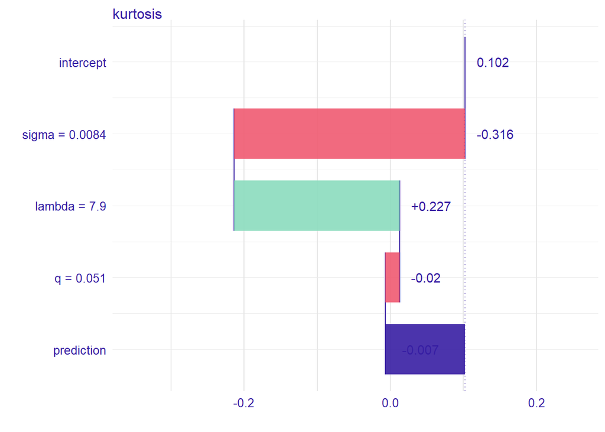

```r
plot(ibd_kurtosis_list[[15]])
```

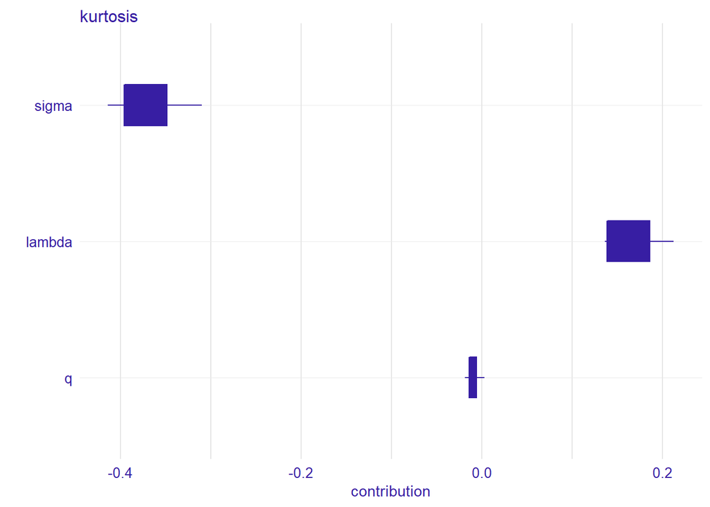

```r
plot(ibdu_kurtosis_list[[1]])
```

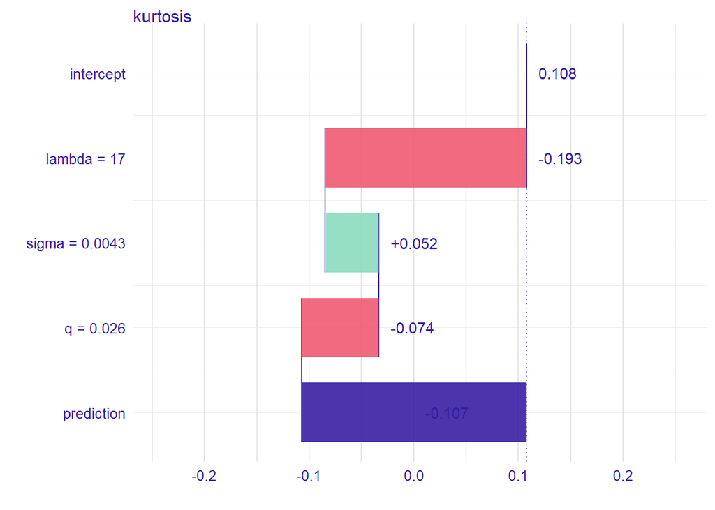

```r
plot(ibd_kurtosis_list[[1]])
```

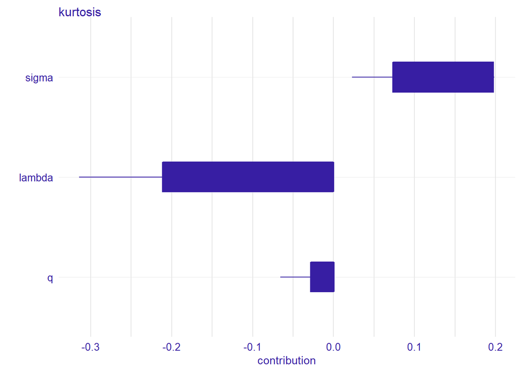

```r
plot(ibdu_kurtosis_list[[2]])
```

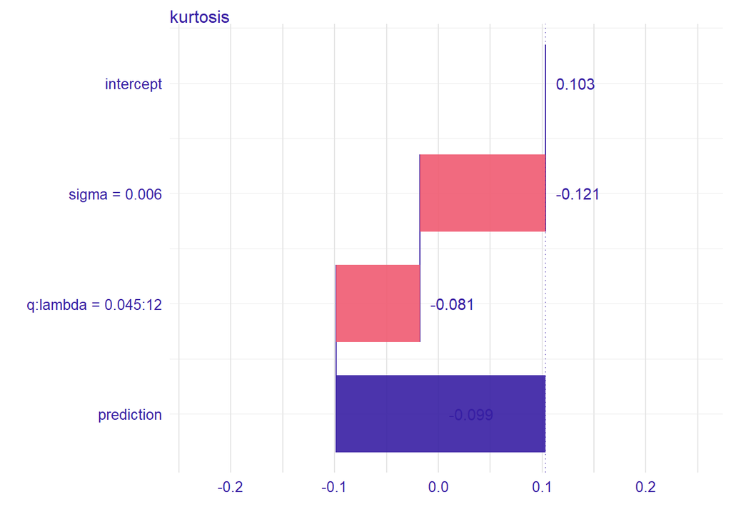

```r
plot(ibd_kurtosis_list[[14]])
```

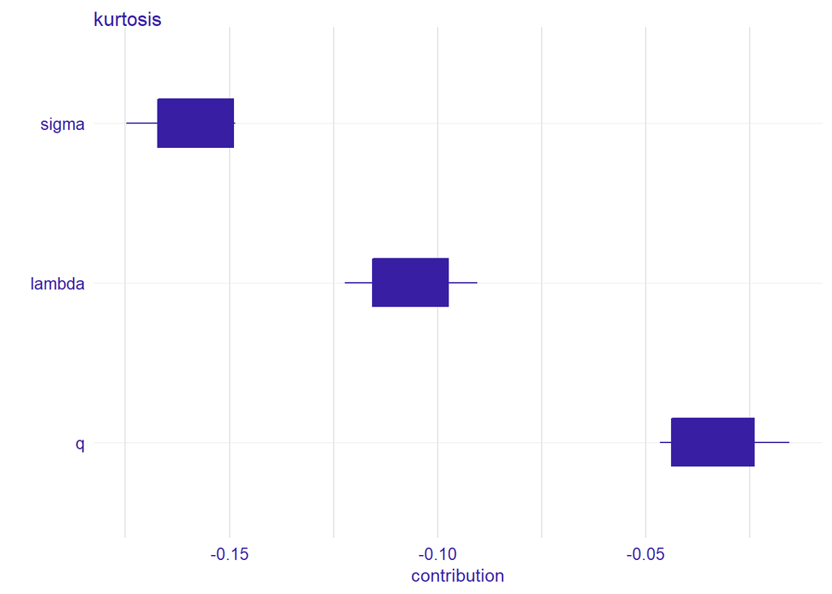

```r
plot(ibdu_kurtosis_list[[3]])
```

## 1.2 Std

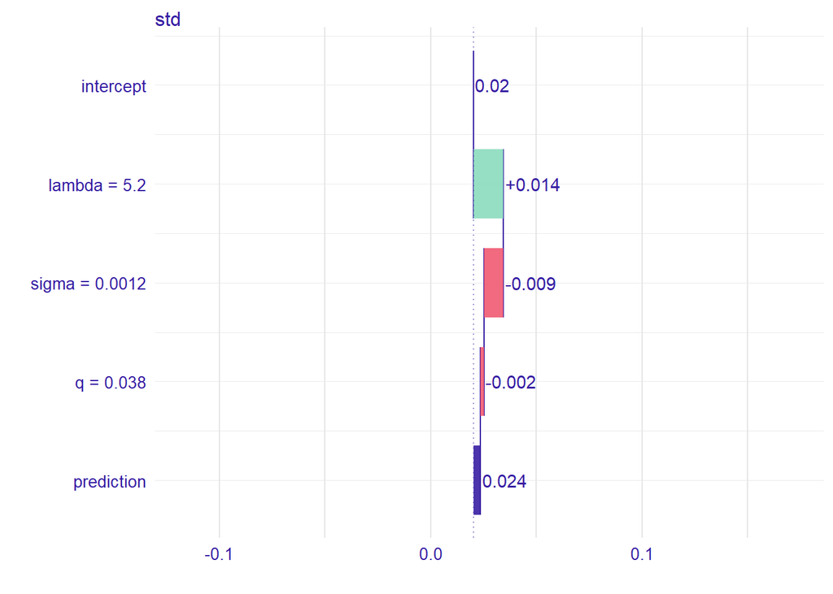

```r
plot(ibd_std_list[[3]])
```

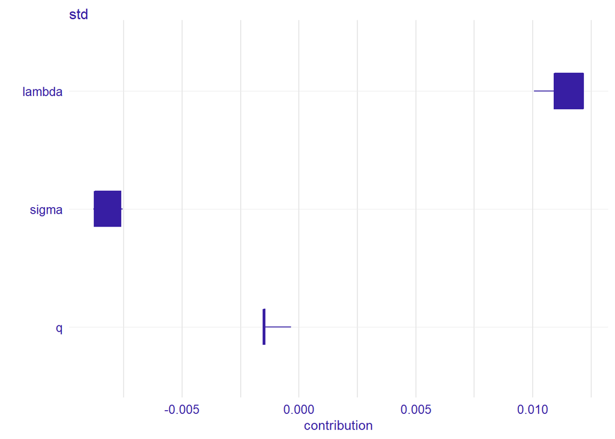

```r
plot(ibdu_std_list[[4]])
```

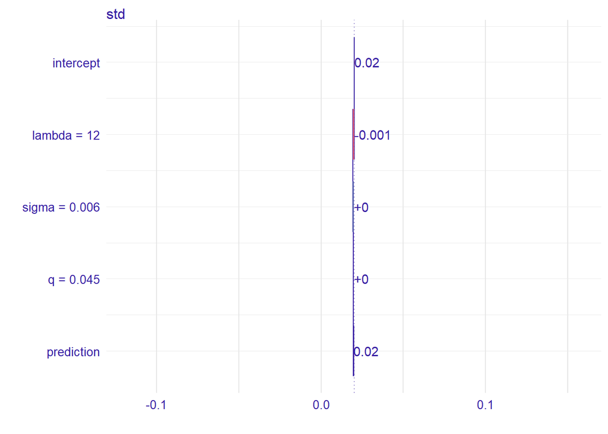

```r
plot(ibd_std_list[[14]])
```

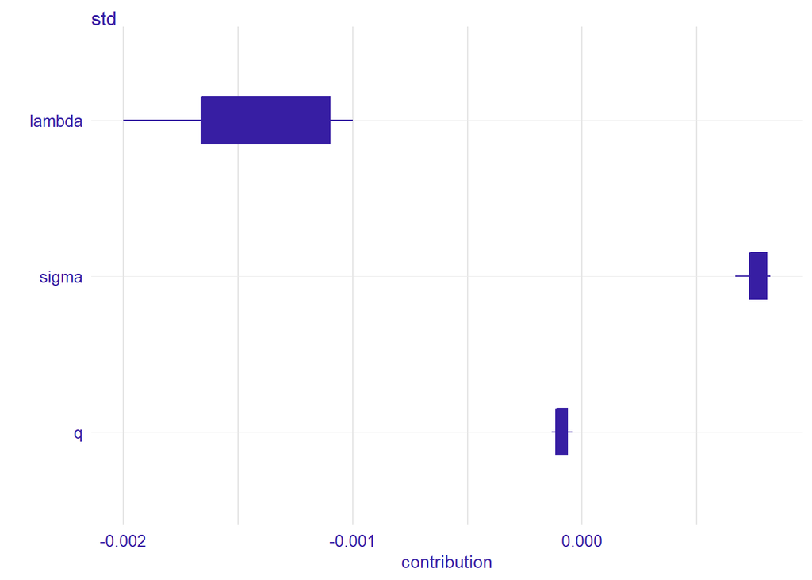

```r
plot(ibdu_std_list[[3]])
```

# 2 Ceteris Paribus 1D plots

Green lines are individual variable profiles for all observations. Individual Variable Profiles show how the model response change when one of the coordinates of single observation changes.

Blue line is the partial dependence plot, it shows how the expected model response behaves as a function of a selected feature. We can think about them an average from Ceteris Paribus Profiles.

## 2.1 Mean

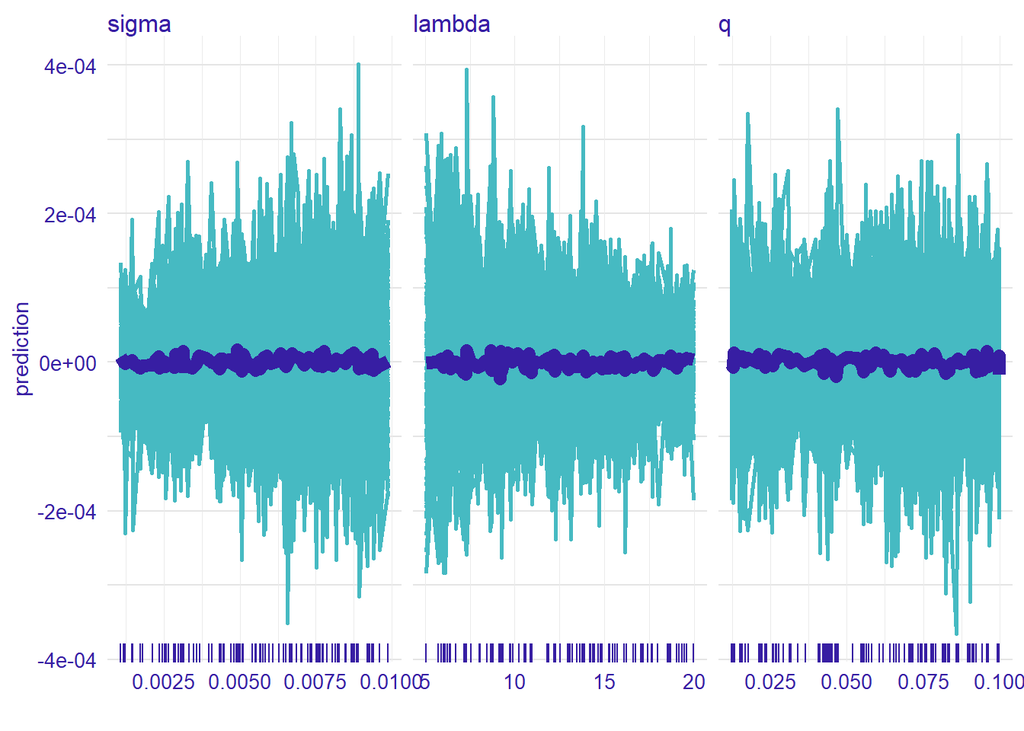

```r
ap_mean <- aggregate_profiles(cp_mean)
plot(cp_mean) + show_aggreagated_profiles(ap_mean, size = 3) +  show_rugs(cp_mean)
```

## 2.2 Std

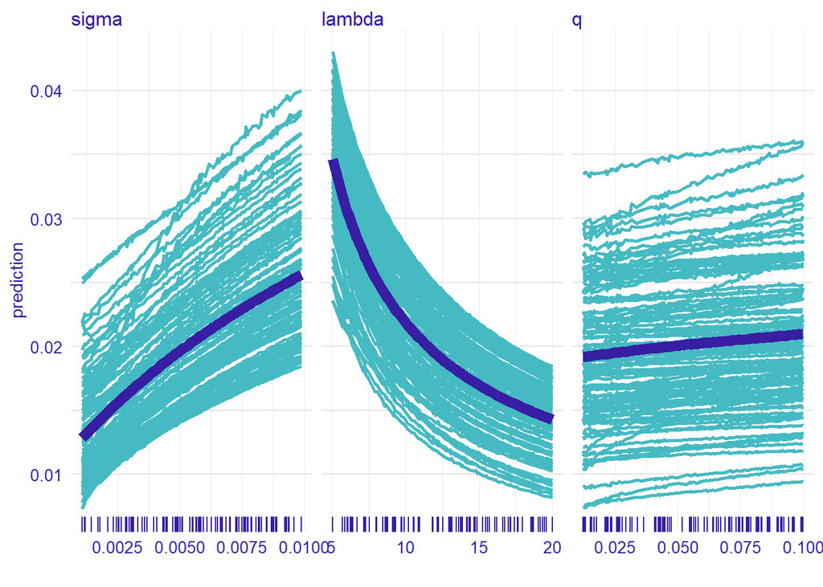

```r
ap_std <- aggregate_profiles(cp_std)
plot(cp_std) + show_aggreagated_profiles(ap_std, size = 3) +  show_rugs(cp_std)
```

## 2.3 Kurthosis

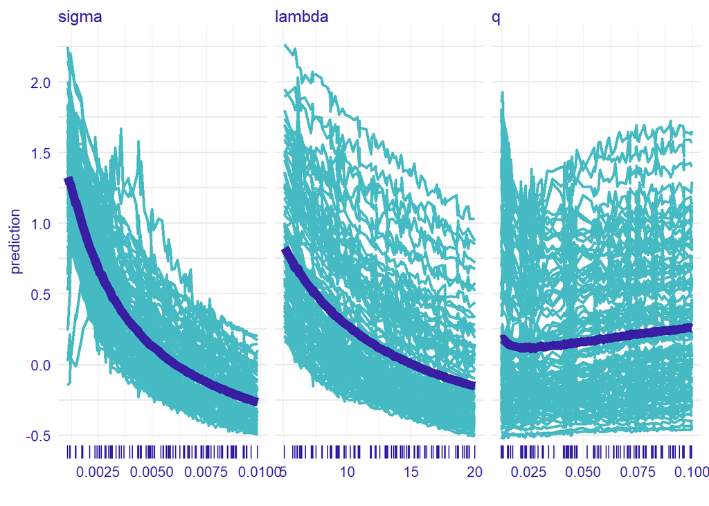

```r
ap_kurtosis <- aggregate_profiles(cp_kurtosis)
plot(cp_kurtosis) + show_aggreagated_profiles(ap_kurtosis, size = 3) +  show_rugs(cp_kurtosis)
```

## 2.4 Skewness

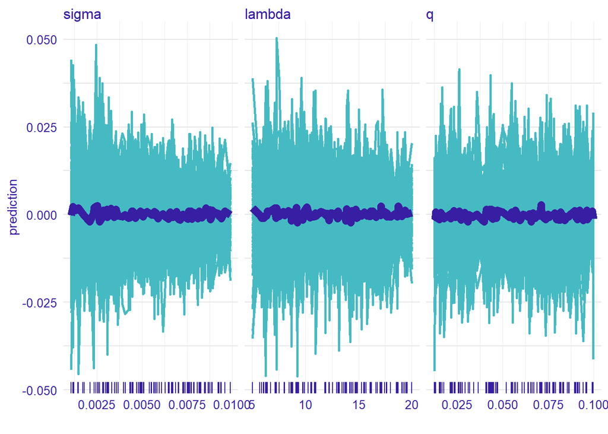

```r
ap_skewness <- aggregate_profiles(cp_skewness)
plot(cp_skewness) + show_aggreagated_profiles(ap_skewness, size = 3) +  show_rugs(cp_skewness)
```

# 3 Ceteris Paribus 2D plot

Ceteros Paribus 2D plots shows grid of values spanned by two variables. Pluses mark observation that are explained.

## 3.1 Mean

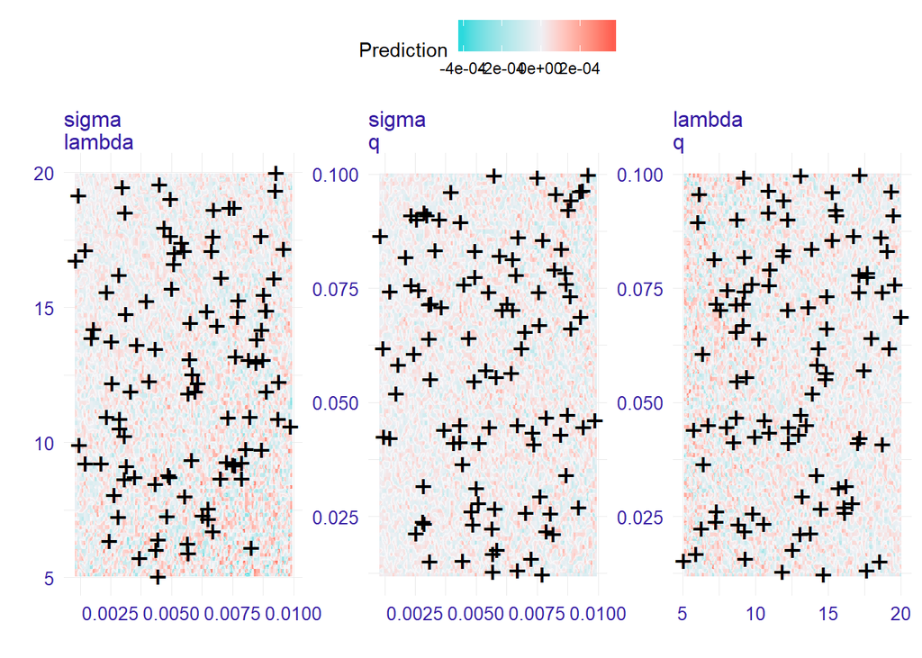

```r
plot(cp_2d_mean)
```

## 3.2 Std

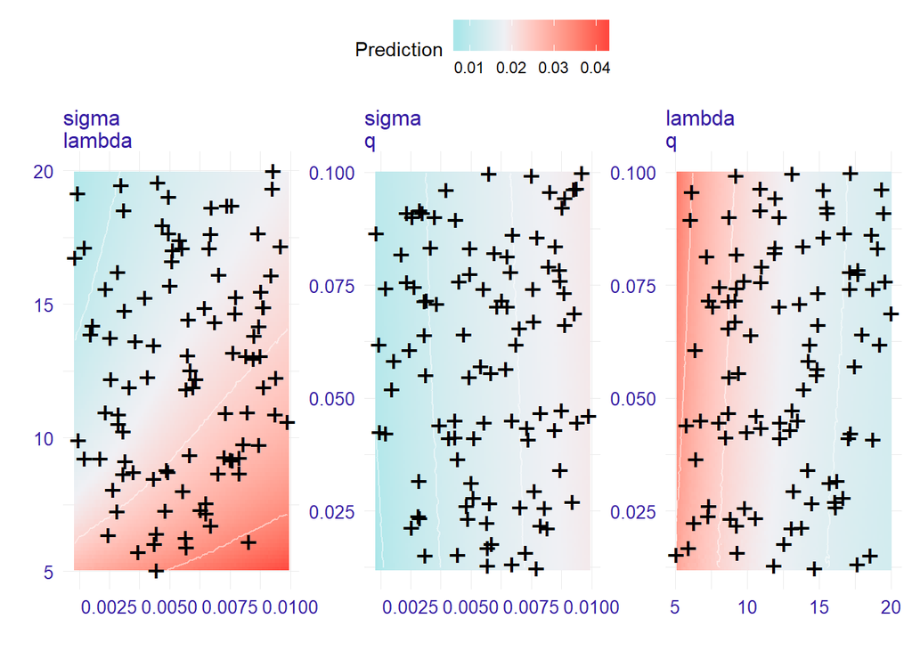

```r
plot(cp_2d_std)
```

## 3.3 Kurthosis

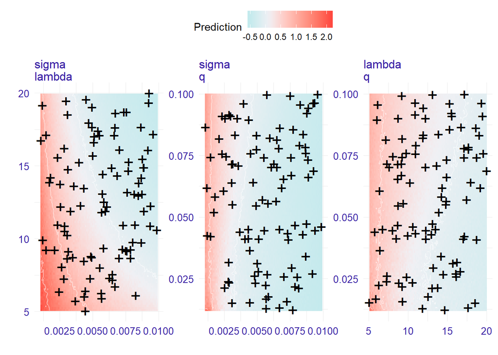

```r
plot(cp_2d_kurtosis)
```

## 3.4 Skewness

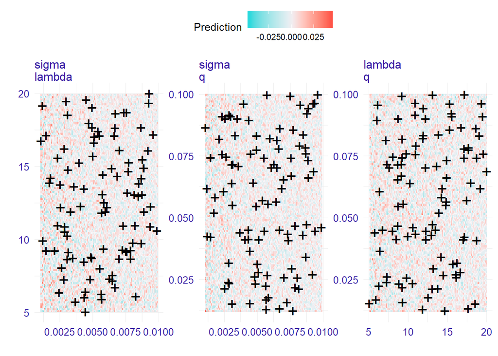

```r
plot(cp_2d_skewness)
```